# Analyse climat ↔︎ CO2 mondial

### 4.4.7 DLWRF — LW descendant surface

**Tendance Sen** : +0.1177 / an (IC 95 % bootstrap : [0.07576 ; 0.1593])  
**Mann-Kendall** : tau = 0.155, p = 0  
**Évolution sur 47 ans** : +1.62 % de la moyenne (341.2)

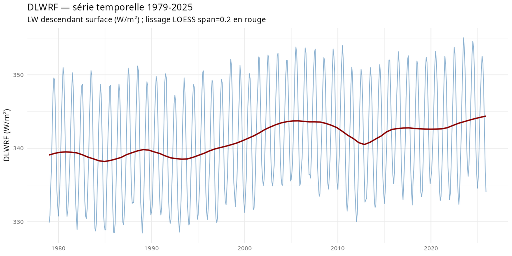

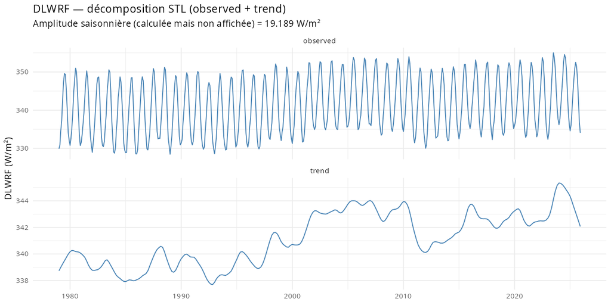

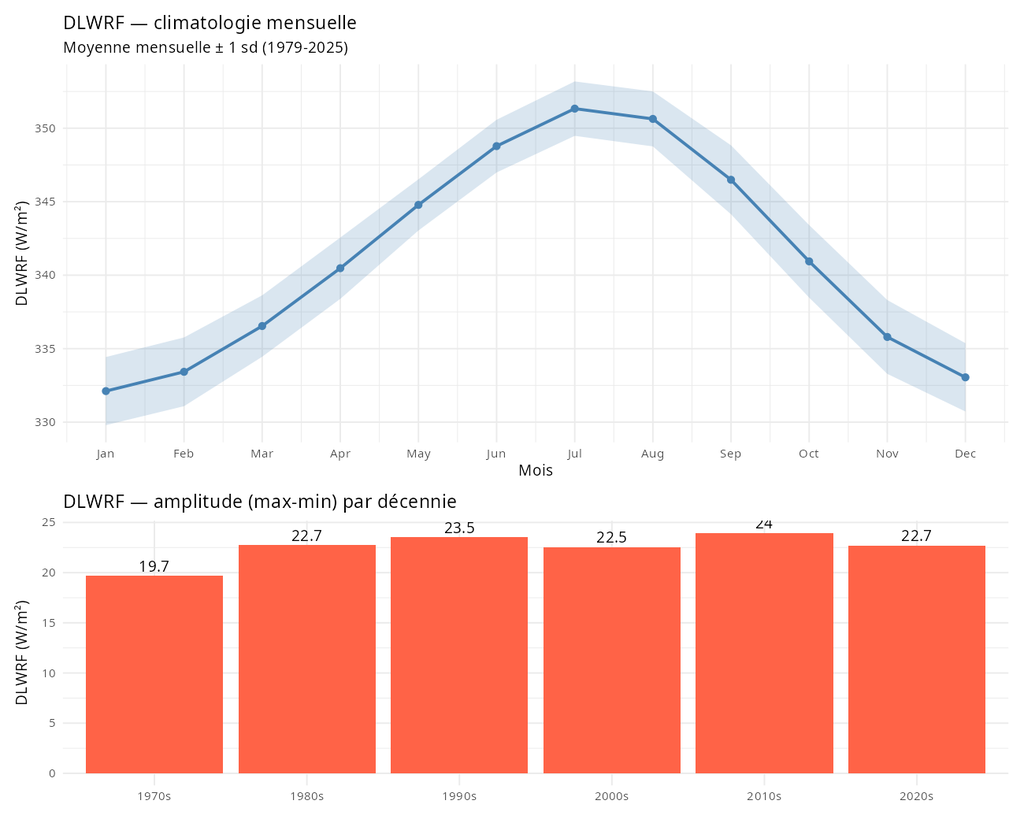

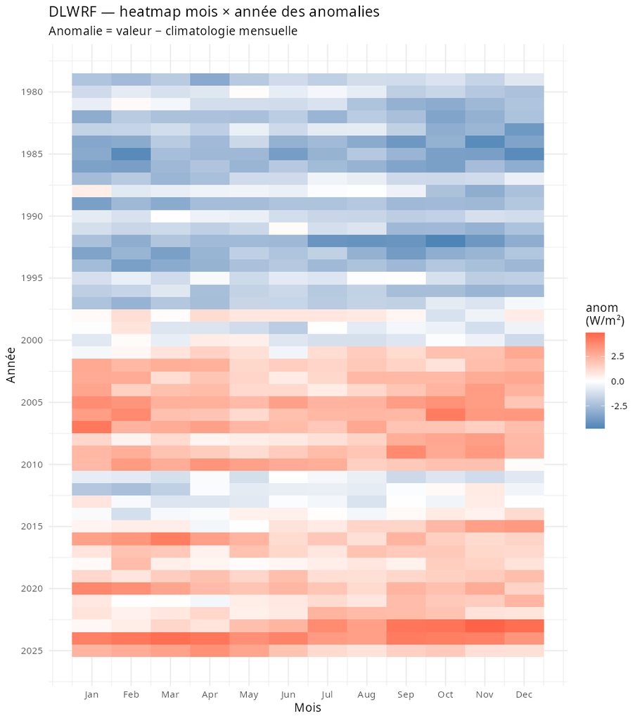

### 4.4.8 ULWRF — LW ascendant surface

**Tendance Sen** : +0.08642 / an (IC 95 % bootstrap : [0.05551 ; 0.1178])  
**Mann-Kendall** : tau = 0.137, p = 1.07e-06  
**Évolution sur 47 ans** : +1.02 % de la moyenne (398.1)

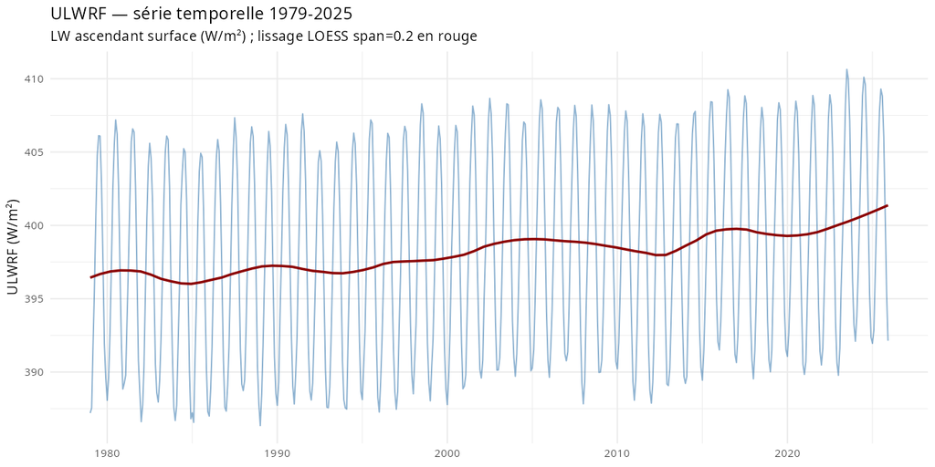

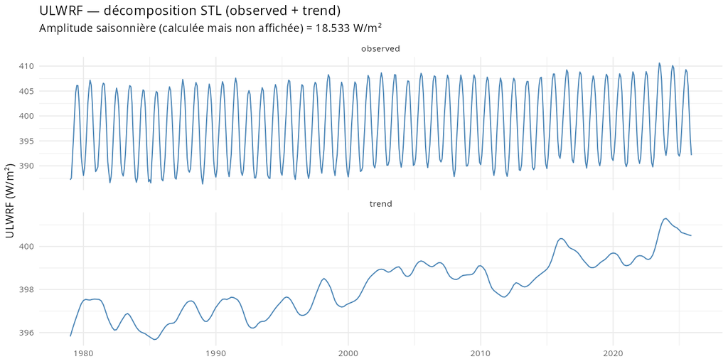

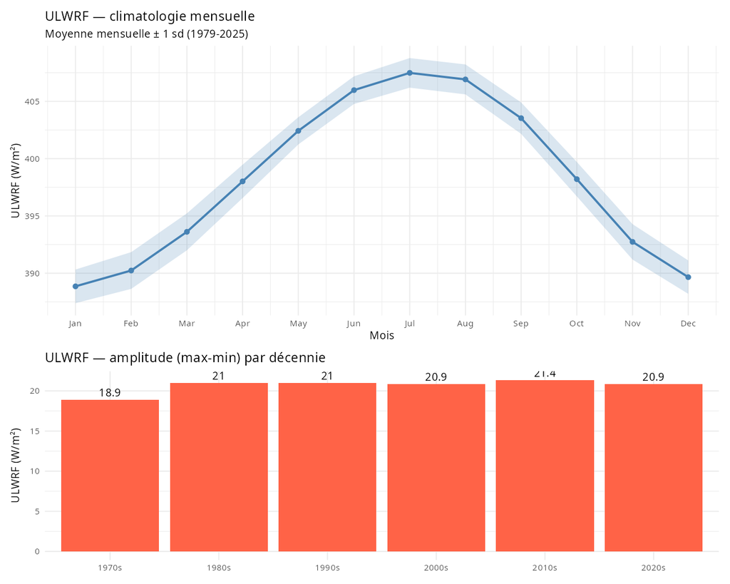

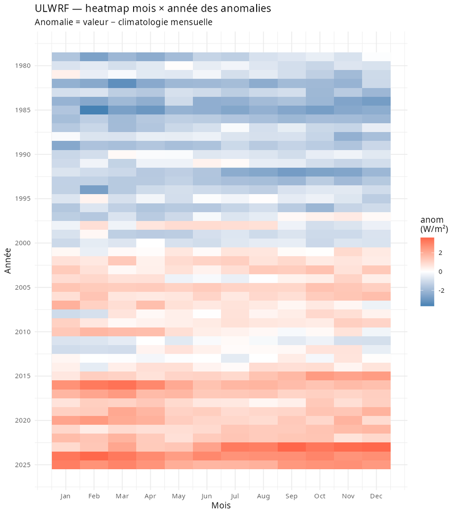

### 4.4.9 DSWRF — SW descendant surface

**Tendance Sen** : +0.08215 / an (IC 95 % bootstrap : [0.04305 ; 0.1134])  
**Mann-Kendall** : tau = 0.124, p = 1.05e-05  
**Évolution sur 47 ans** : +1.99 % de la moyenne (194)

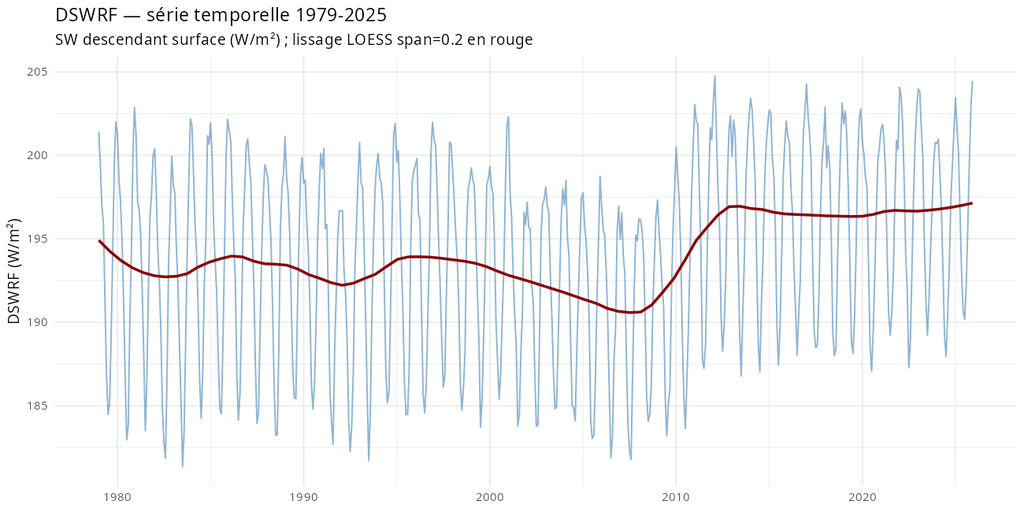

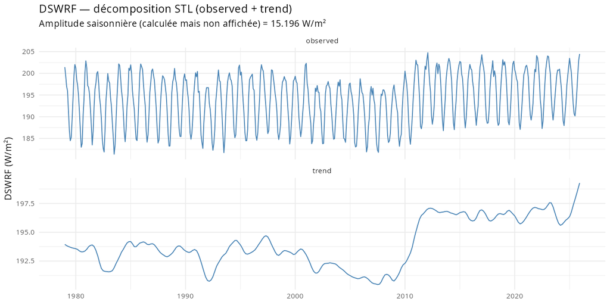

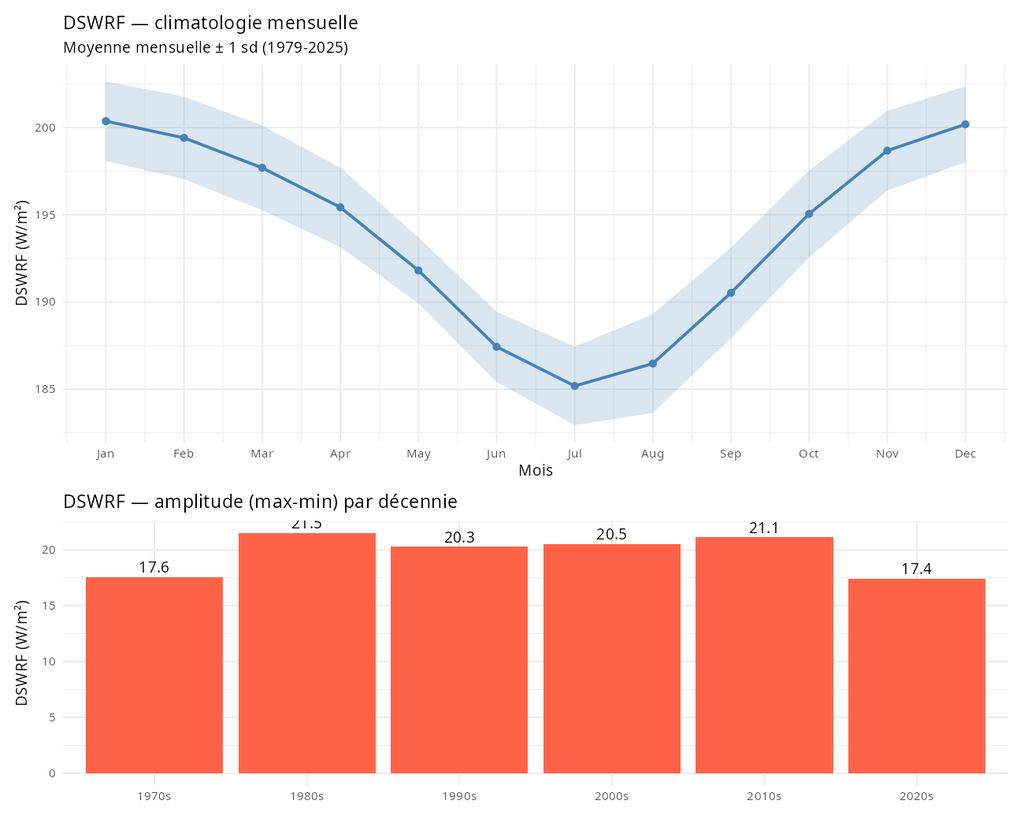

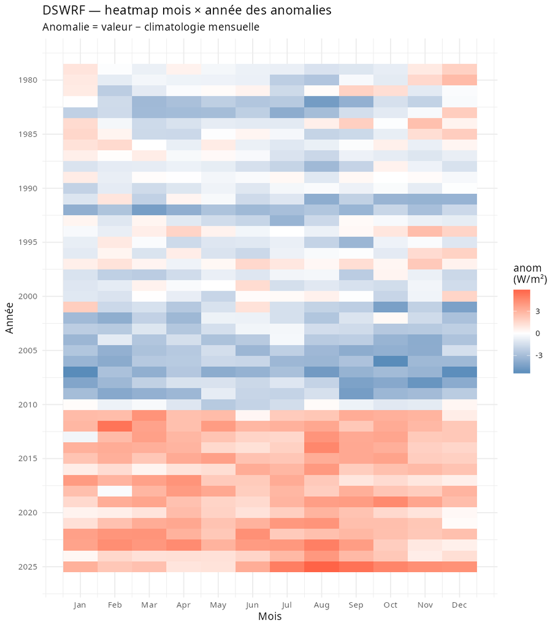

### 4.4.10 USWRF — SW réfléchi surface

**Tendance Sen** : +0.00582 / an (IC 95 % bootstrap : [-0.006099 ; 0.0198])  
**Mann-Kendall** : tau = 0.025, p = 0.367  
**Évolution sur 47 ans** : +1.05 % de la moyenne (26.15)

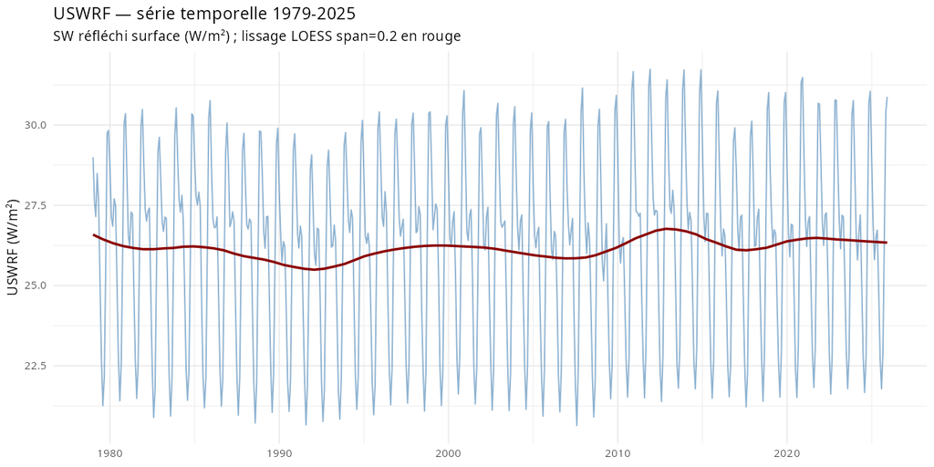

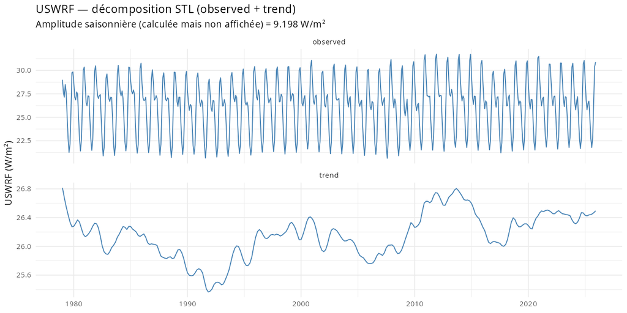

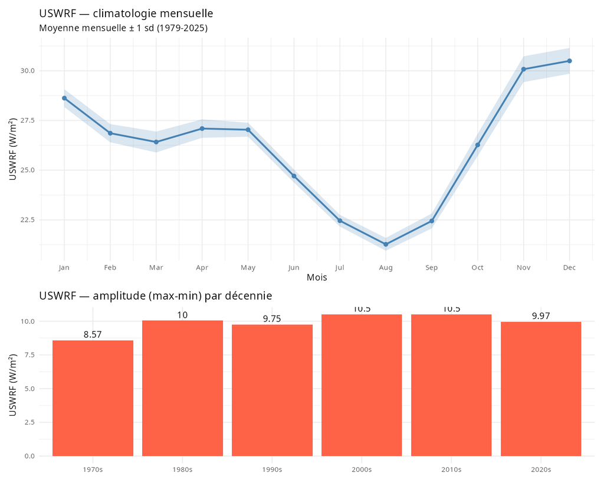

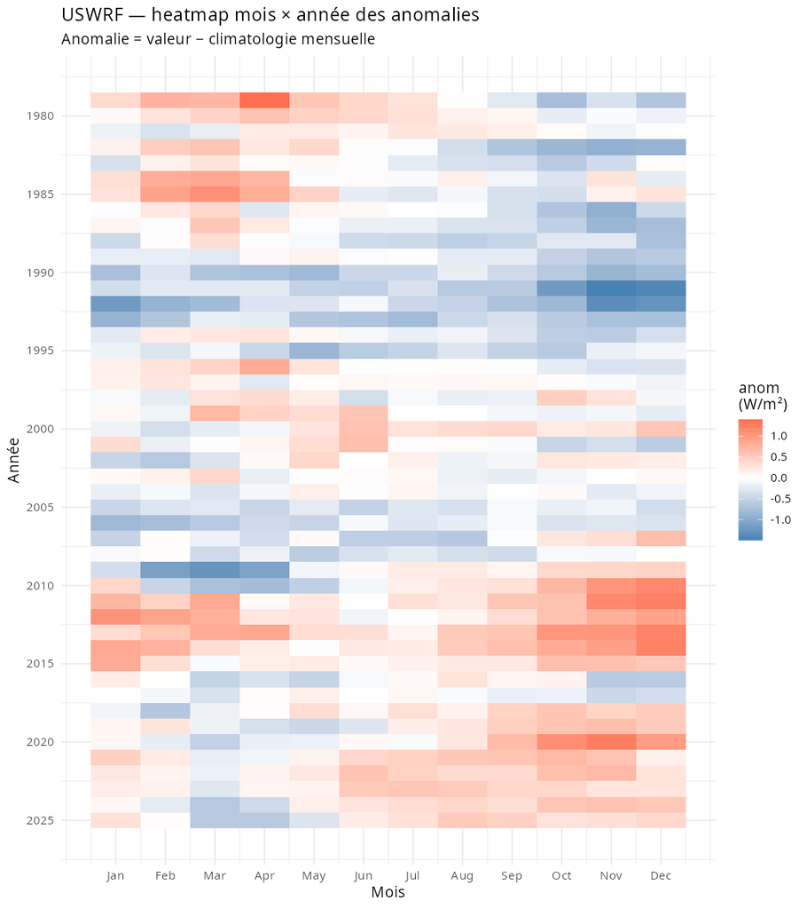

### 4.4.11 PRMSL — Pression réduite mer

**Tendance Sen** : +4.325e-05 / an (IC 95 % bootstrap : [-0.08397 ; 0.08954])  
**Mann-Kendall** : tau = 0.000, p = 0.999  
**Évolution sur 47 ans** : +0.00 % de la moyenne (1.011e+05)

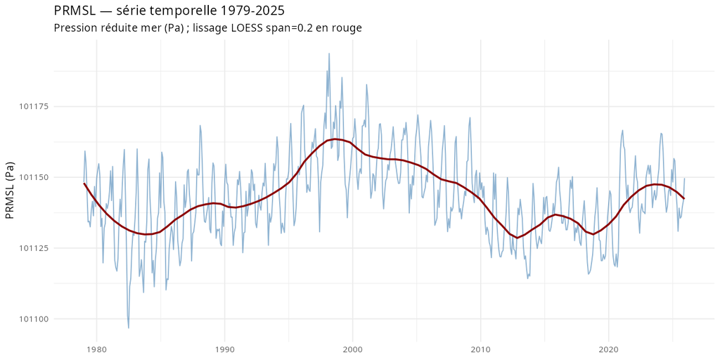

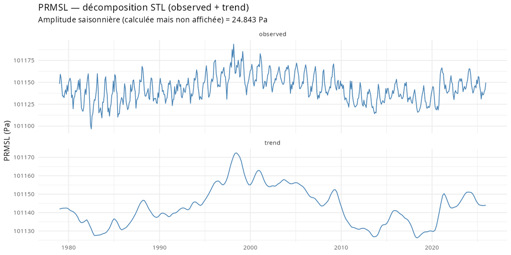

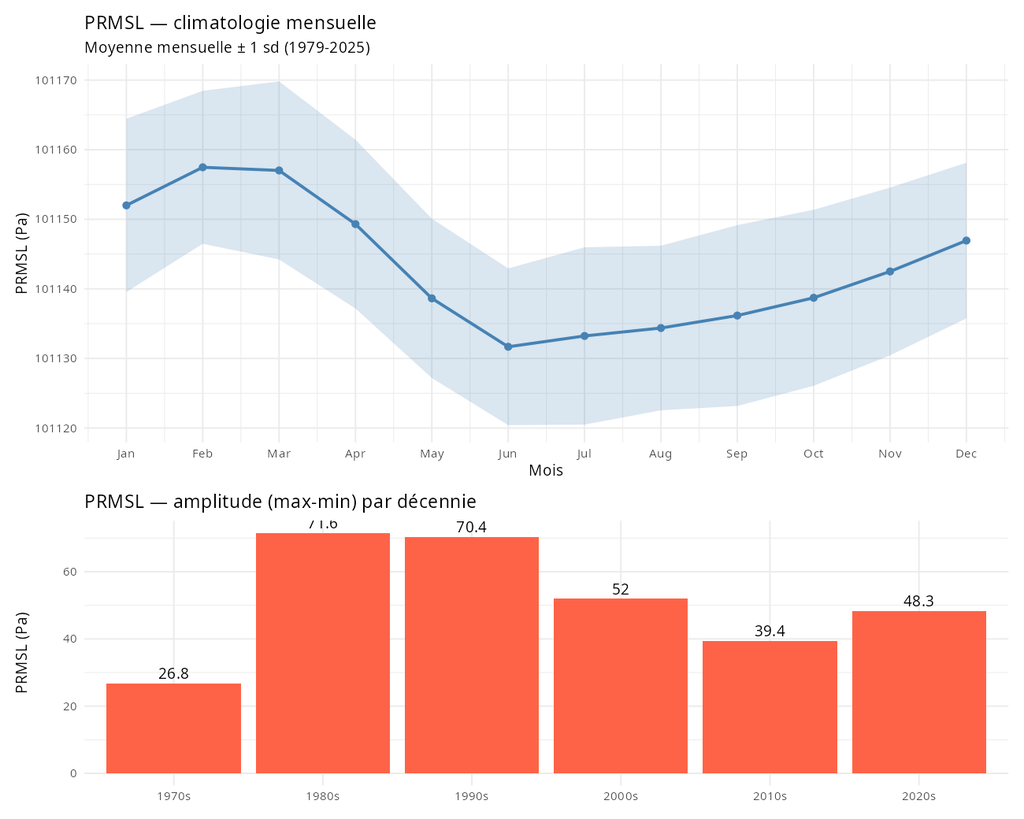

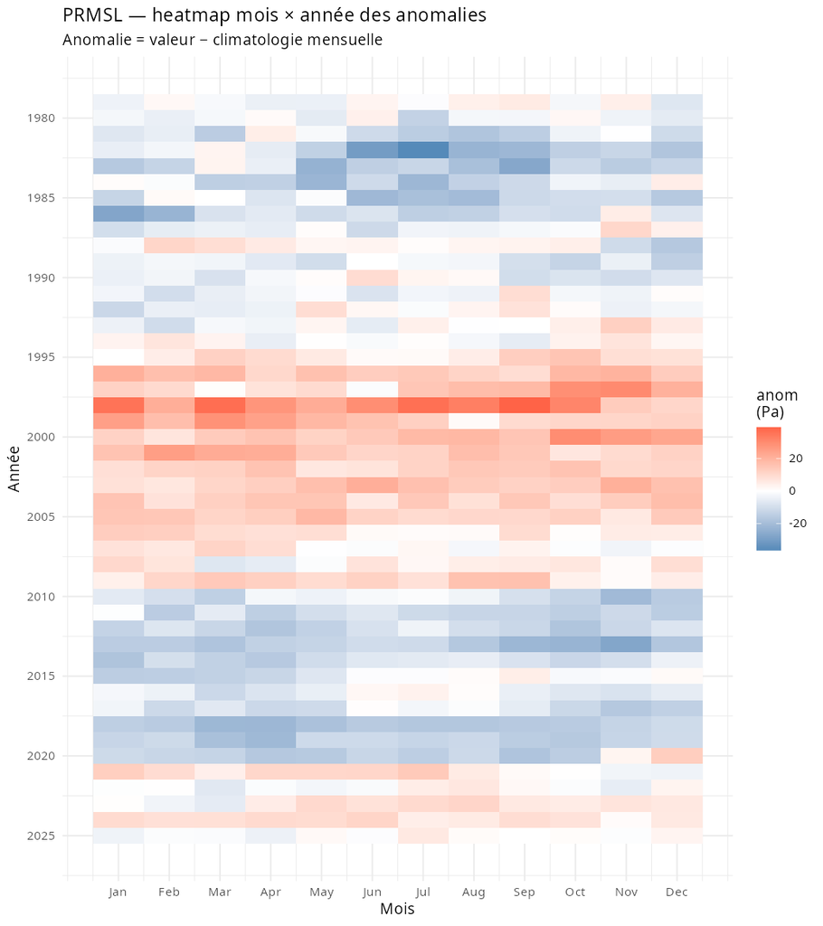

### 4.4.12 CSDSF — SW descendant ciel clair

**Tendance Sen** : -0.01336 / an (IC 95 % bootstrap : [-0.03169 ; 0.01387])  
**Mann-Kendall** : tau = -0.029, p = 0.298  
**Évolution sur 47 ans** : -0.26 % de la moyenne (245.9)

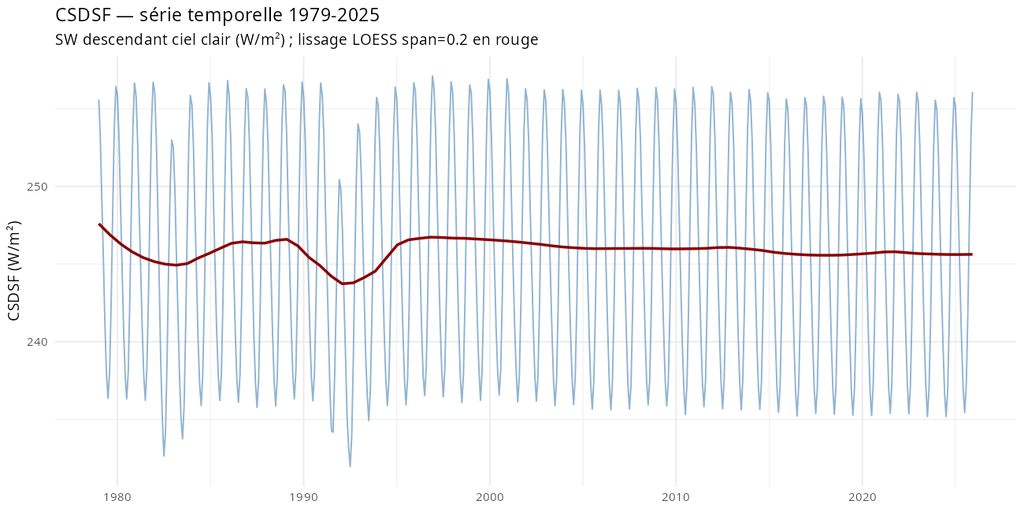

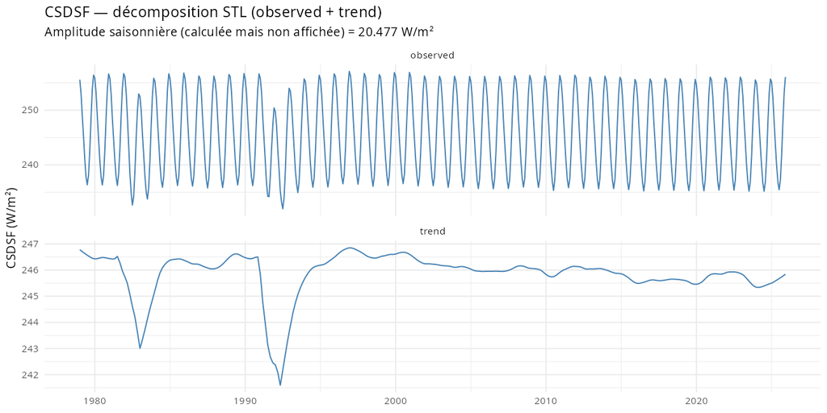

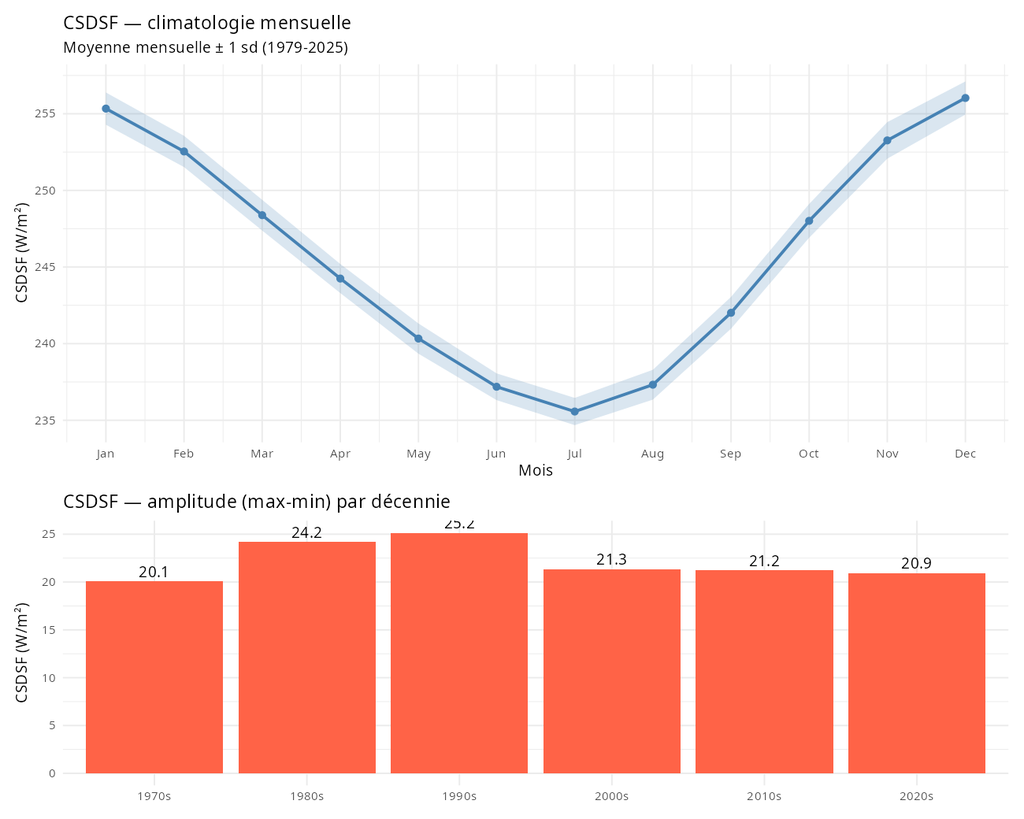

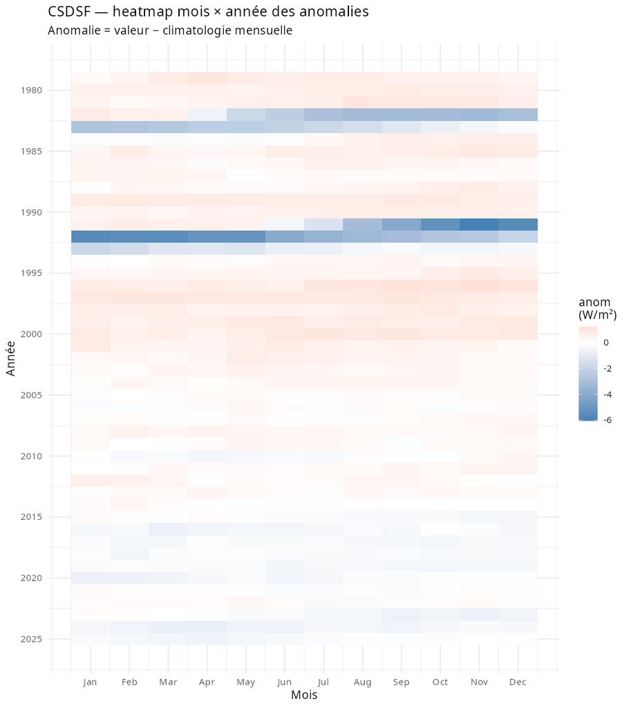

### 4.4.13 CSUSF — SW ascendant ciel clair

**Tendance Sen** : -0.003409 / an (IC 95 % bootstrap : [-0.01673 ; 0.01536])  
**Mann-Kendall** : tau = -0.013, p = 0.644  
**Évolution sur 47 ans** : -0.49 % de la moyenne (32.88)

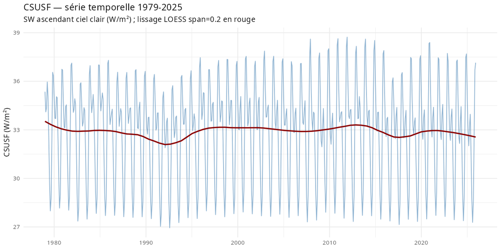

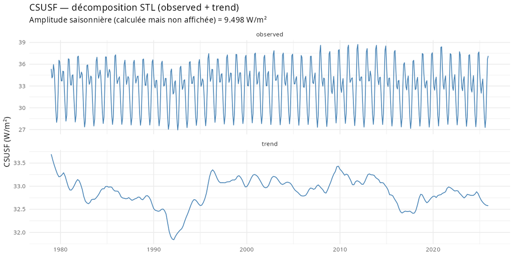

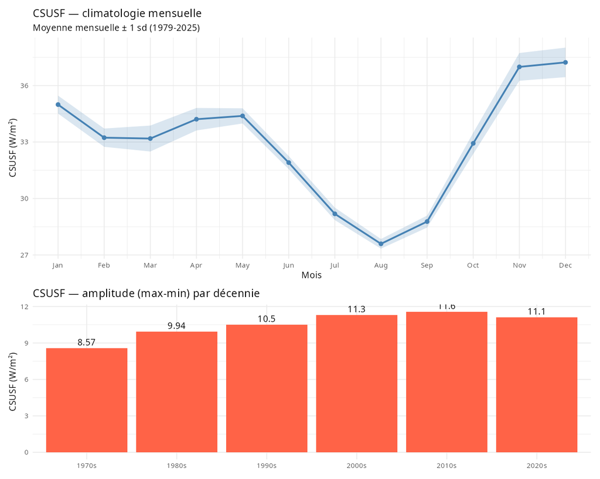

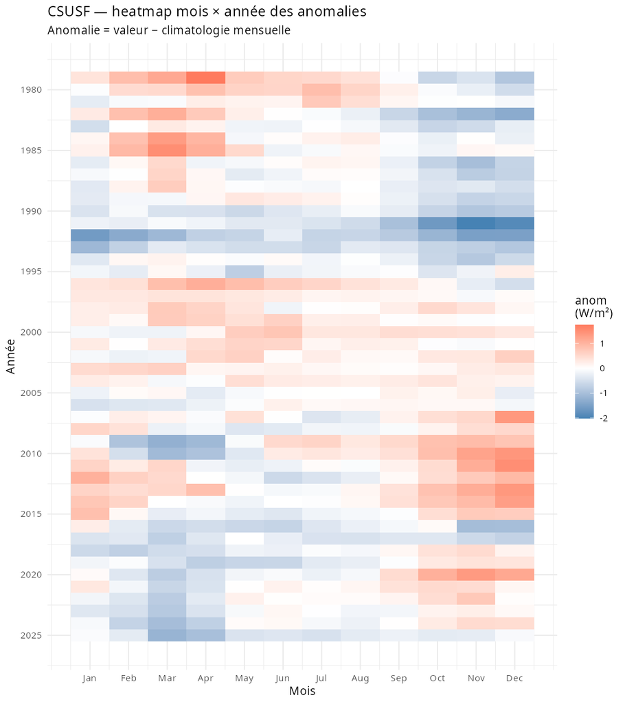

### 4.4.14 CSDLF — LW descendant ciel clair

**Tendance Sen** : +0.1668 / an (IC 95 % bootstrap : [0.1219 ; 0.2024])  
**Mann-Kendall** : tau = 0.214, p = 0  
**Évolution sur 47 ans** : +2.48 % de la moyenne (315.8)

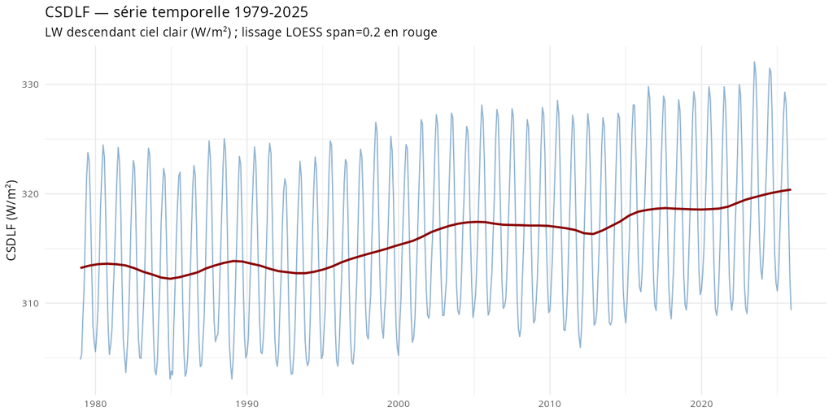

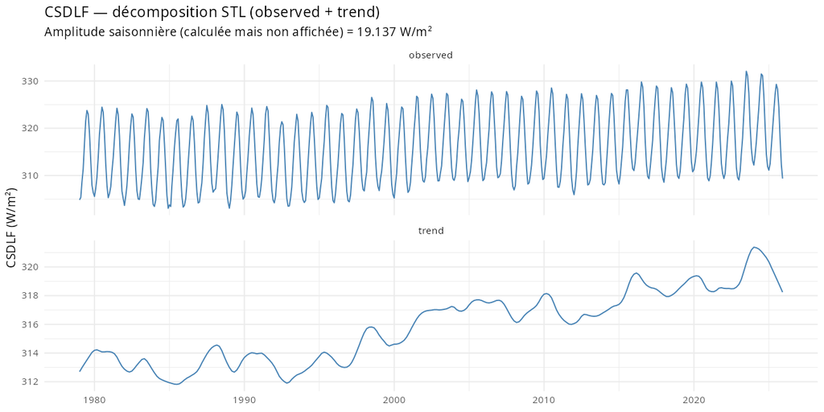

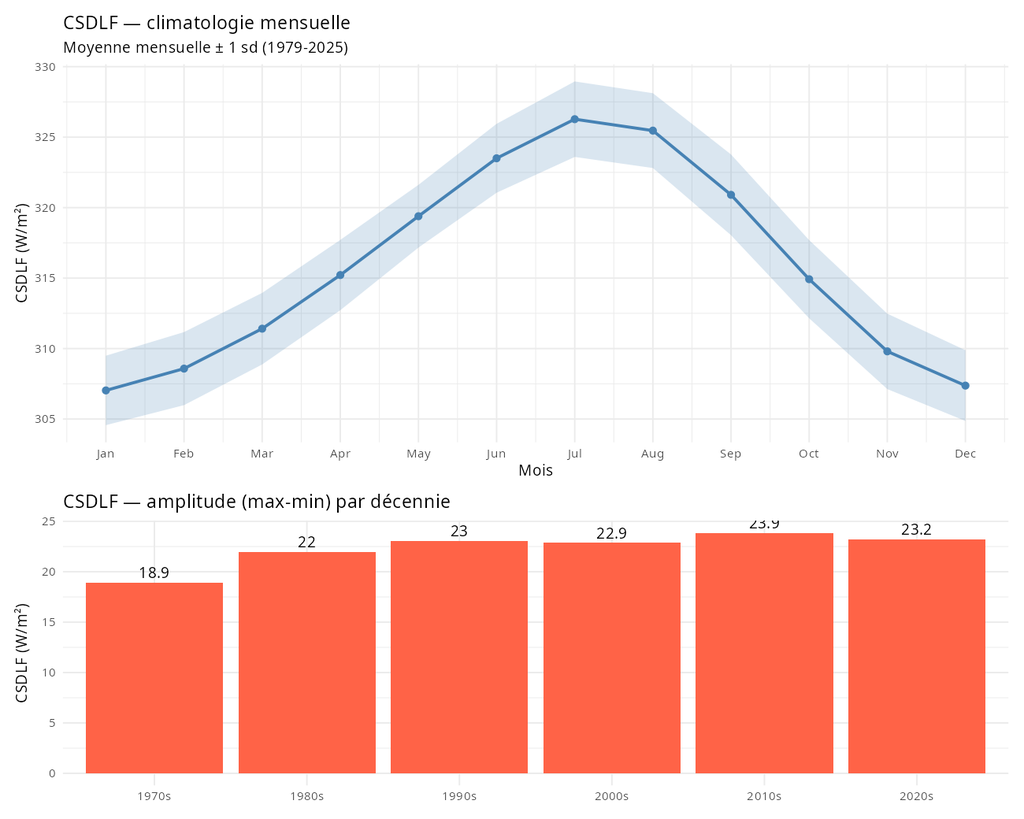

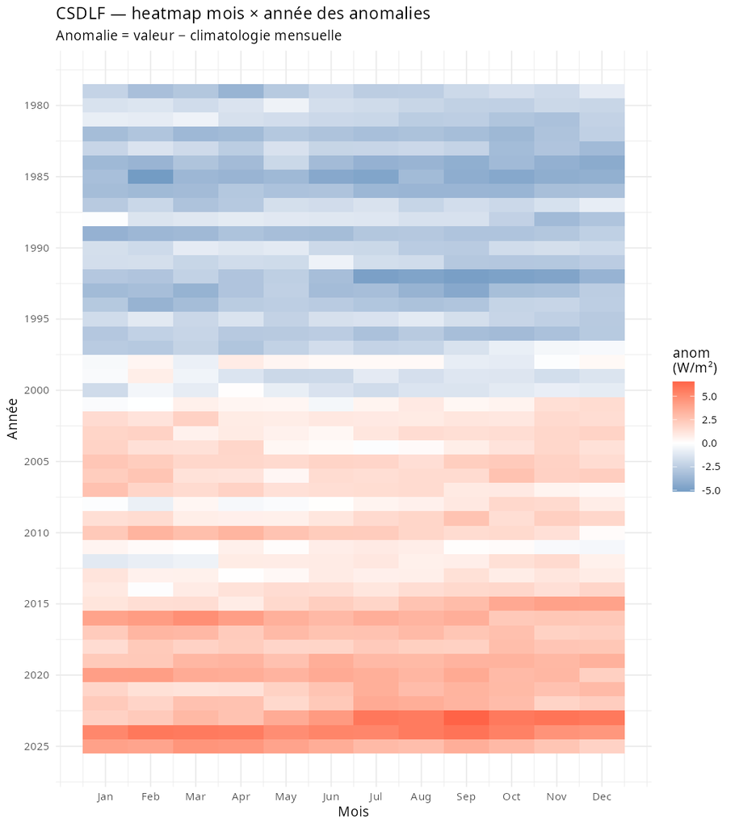

### 4.4.15 CSULF — LW ascendant ciel clair

**Tendance Sen** : +0.08615 / an (IC 95 % bootstrap : [0.05479 ; 0.1169])  
**Mann-Kendall** : tau = 0.137, p = 1.19e-06  
**Évolution sur 47 ans** : +1.02 % de la moyenne (398.1)

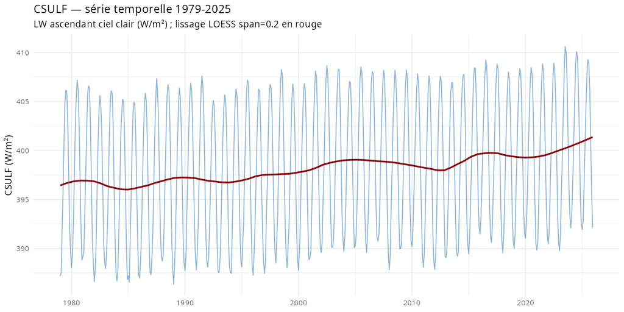

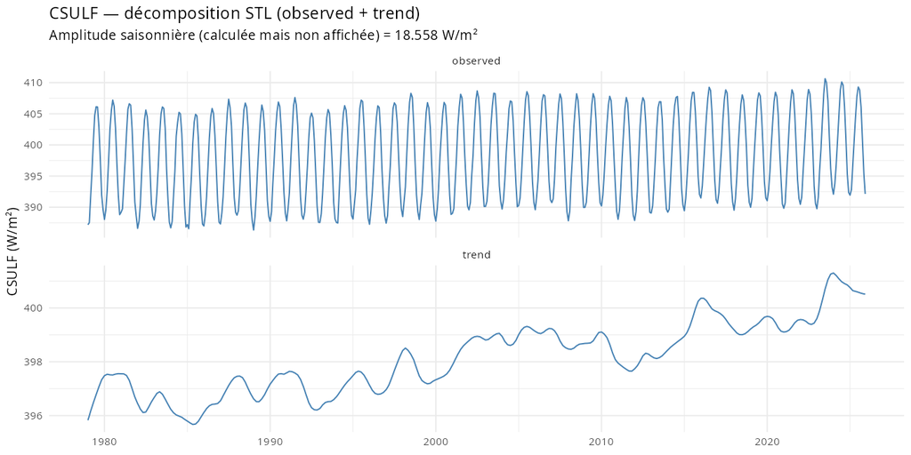

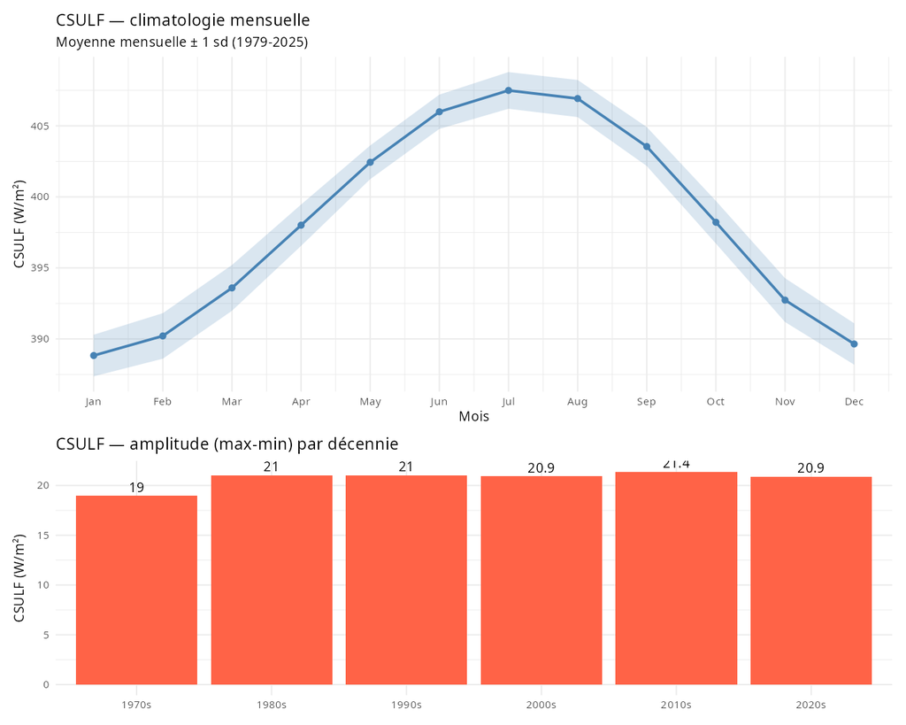

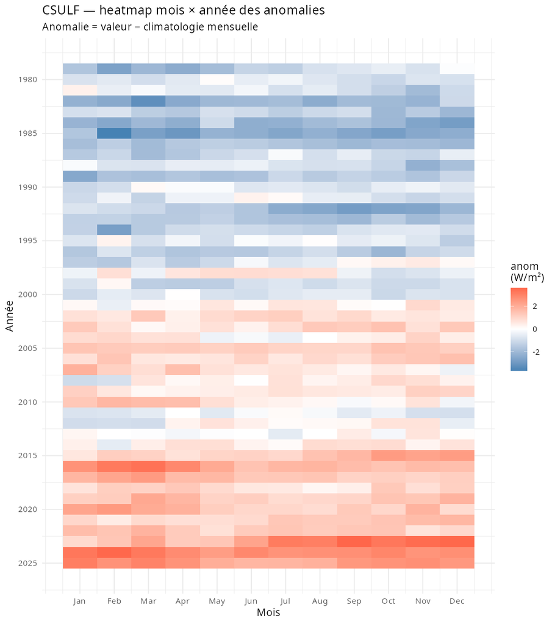

### 4.4.16 CDUVB — UV-B ciel clair

**Tendance Sen** : +0.0009726 / an (IC 95 % bootstrap : [0.0003234 ; 0.001558])  
**Mann-Kendall** : tau = 0.088, p = 0.00169  
**Évolution sur 47 ans** : +1.15 % de la moyenne (3.967)

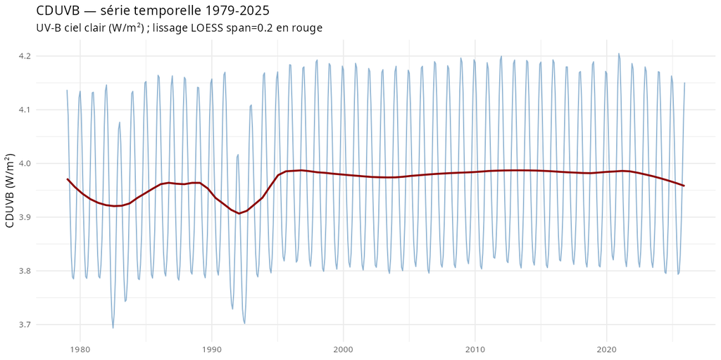

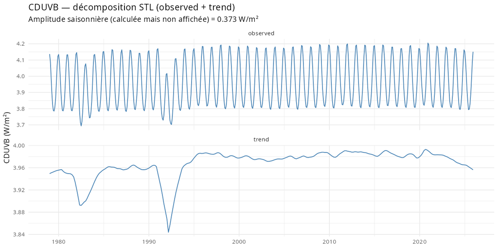

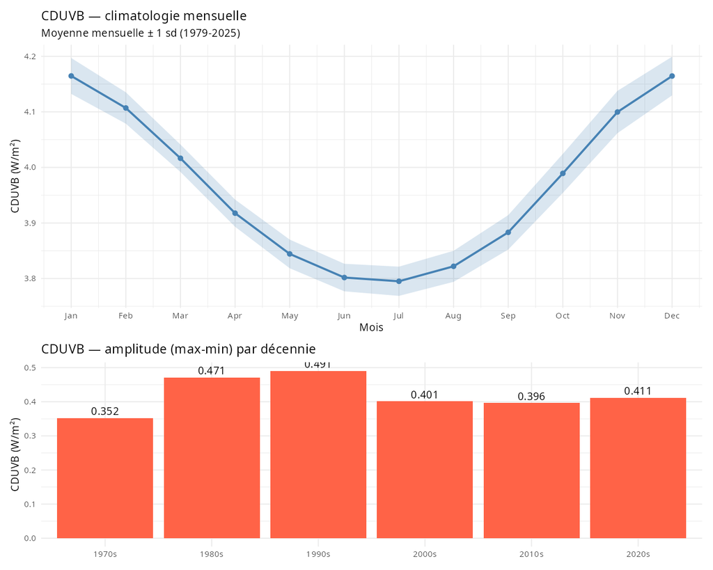

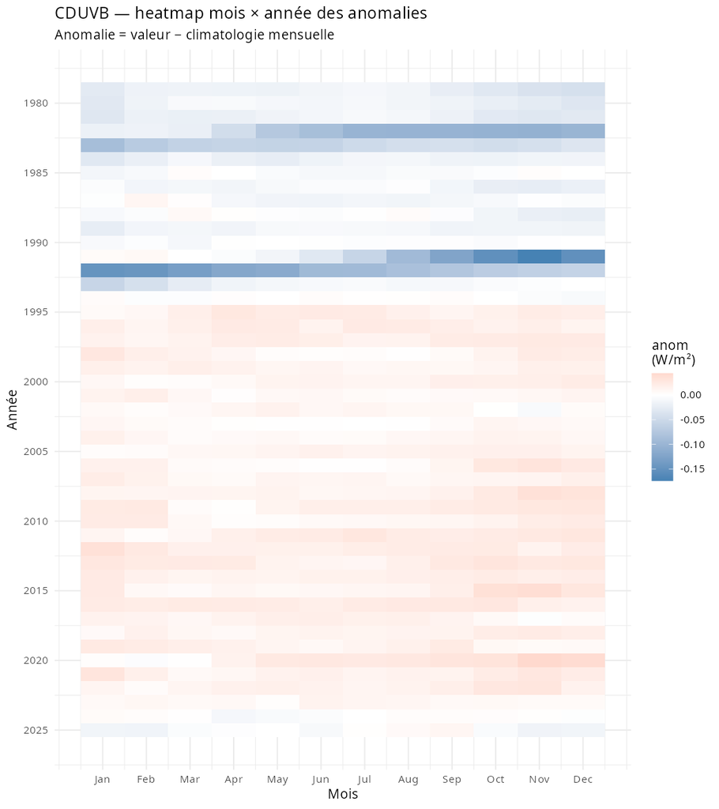

### 4.4.17 DUVB — UV-B all-sky

**Tendance Sen** : +0.002043 / an (IC 95 % bootstrap : [0.001339 ; 0.002665])  
**Mann-Kendall** : tau = 0.161, p = 0  
**Évolution sur 47 ans** : +2.87 % de la moyenne (3.34)

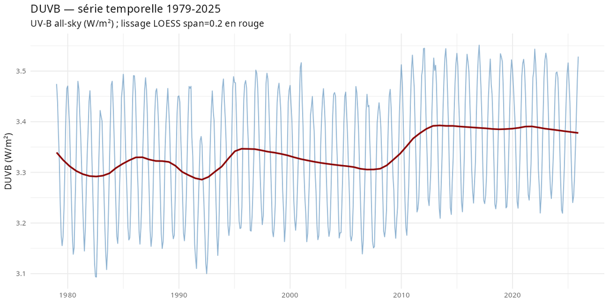

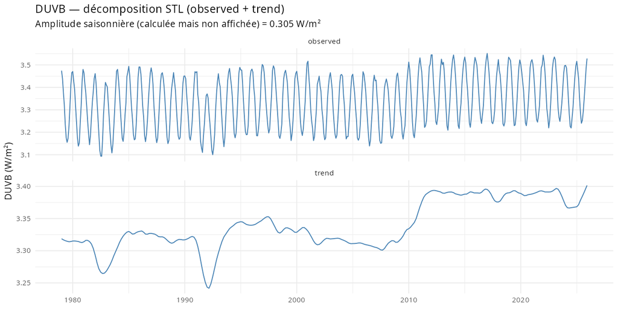

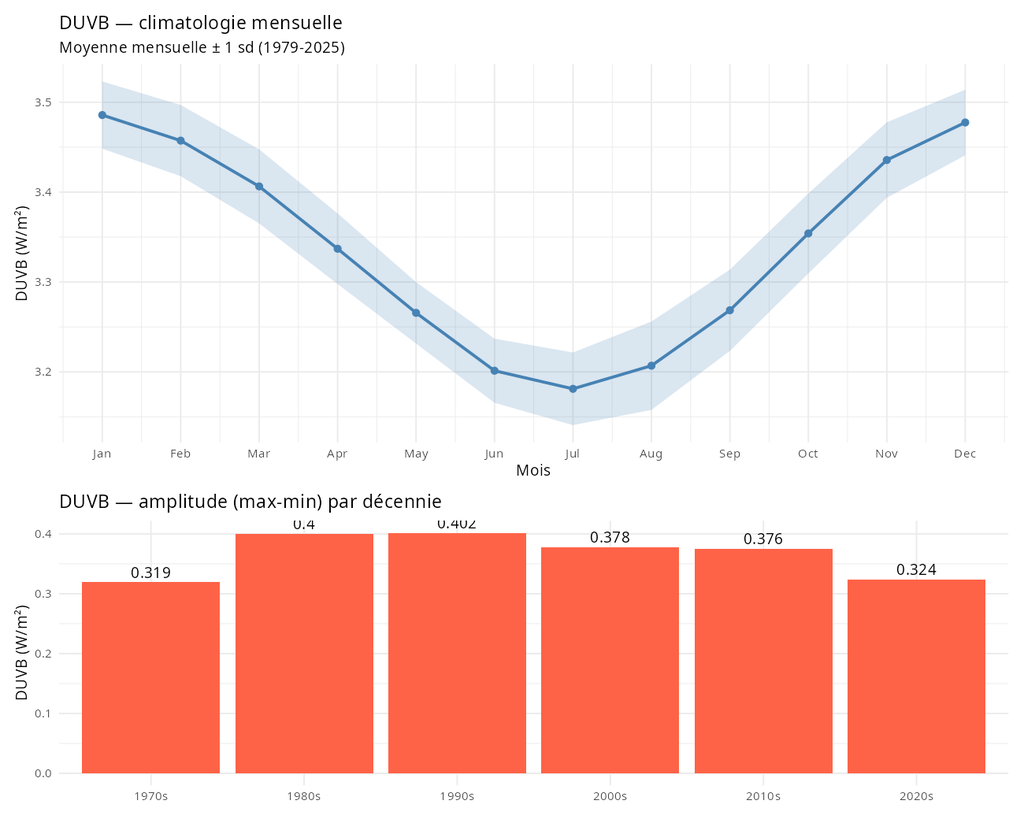

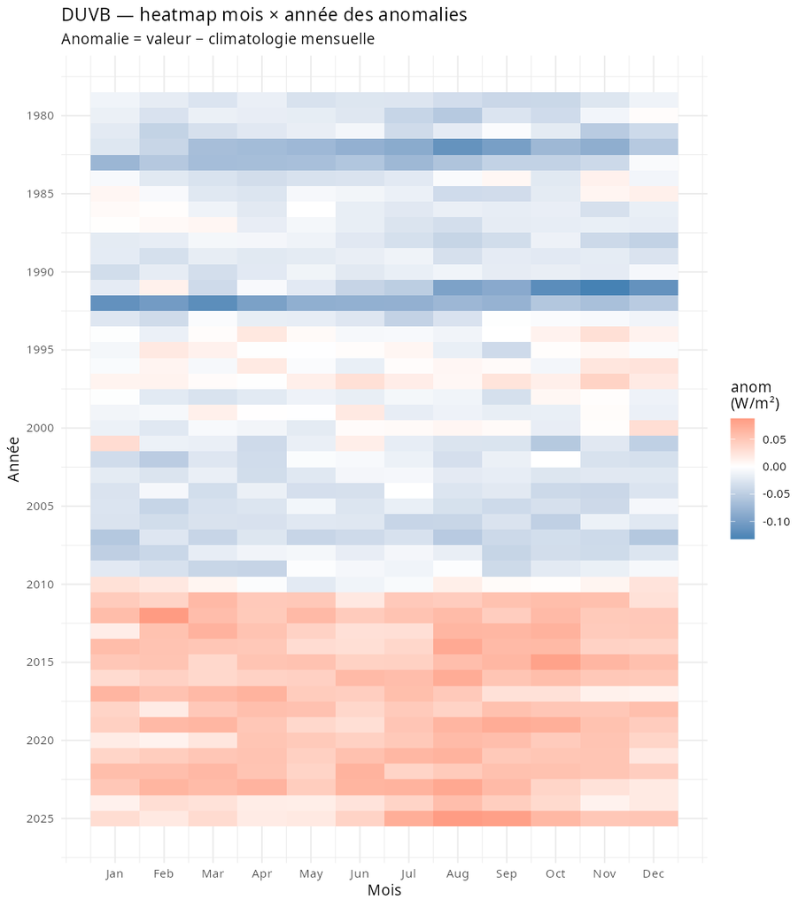

### 4.4.18 ALBDO — Albédo de surface

**Tendance Sen** : -0.0003011 / an (IC 95 % bootstrap : [-0.00588 ; 0.003979])  
**Mann-Kendall** : tau = -0.003, p = 0.907  
**Évolution sur 47 ans** : -0.13 % de la moyenne (10.54)

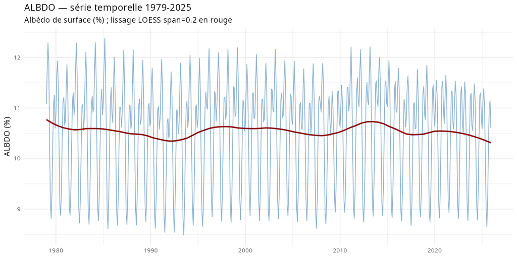

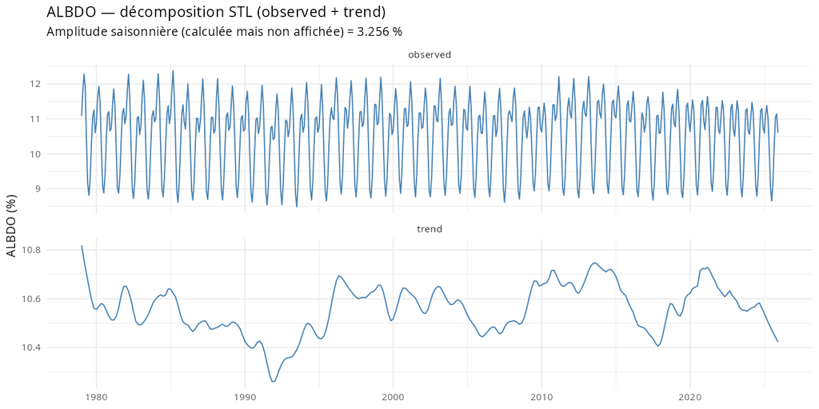

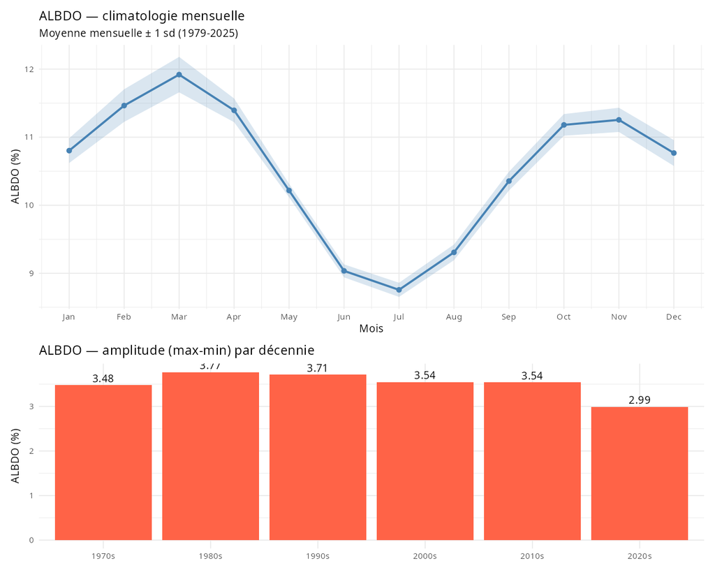

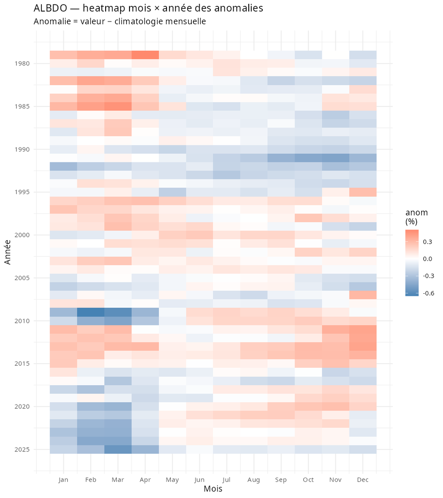

### 4.4.19 CRE_SW — Cloud Radiative Effect SW

**Tendance Sen** : +0.07609 / an (IC 95 % bootstrap : [0.05495 ; 0.09321])  
**Mann-Kendall** : tau = 0.200, p = 0  
**Évolution sur 47 ans** : -7.93 % de la moyenne (-45.1)

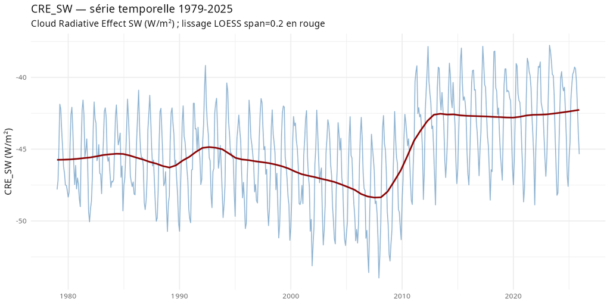

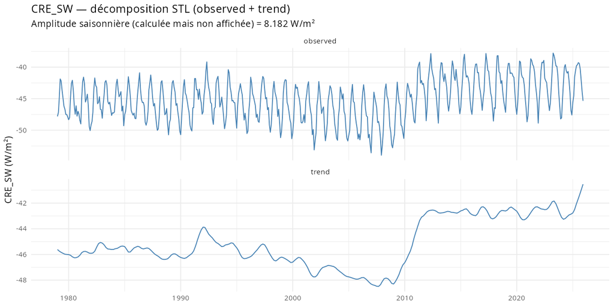

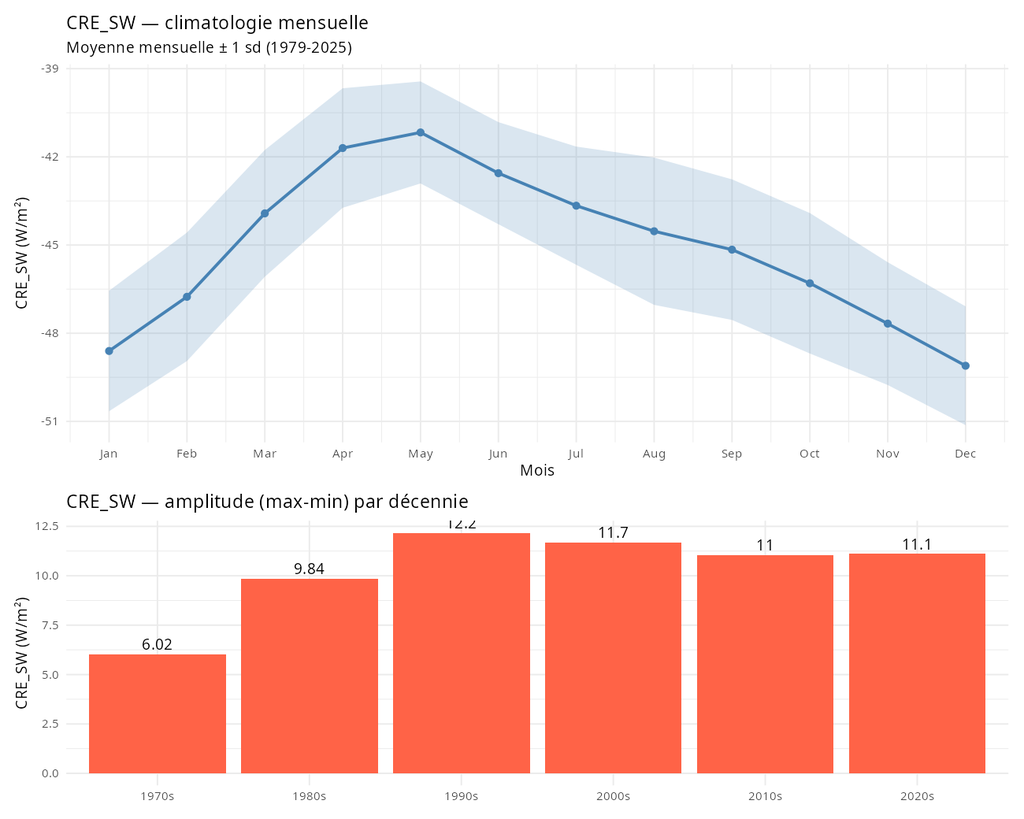

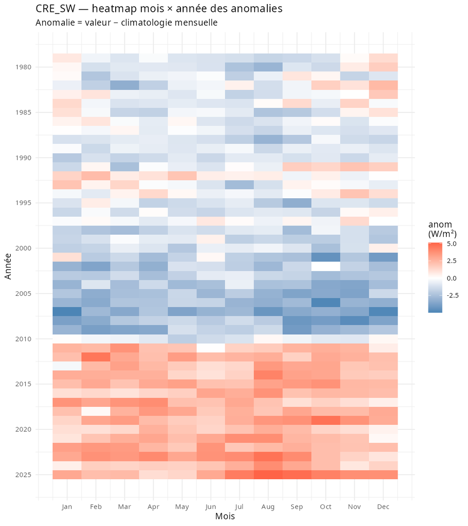

### 4.4.20 CRE_LW — Cloud Radiative Effect LW

**Tendance Sen** : -0.04813 / an (IC 95 % bootstrap : [-0.05305 ; -0.04133])  
**Mann-Kendall** : tau = -0.400, p = 0  
**Évolution sur 47 ans** : -8.92 % de la moyenne (25.37)

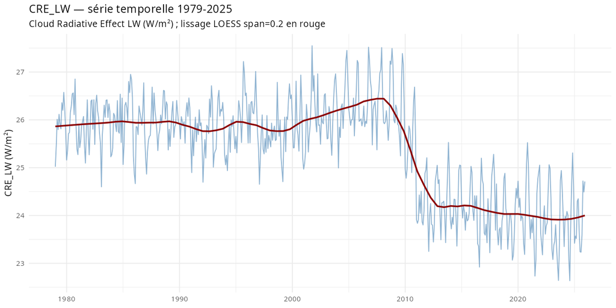

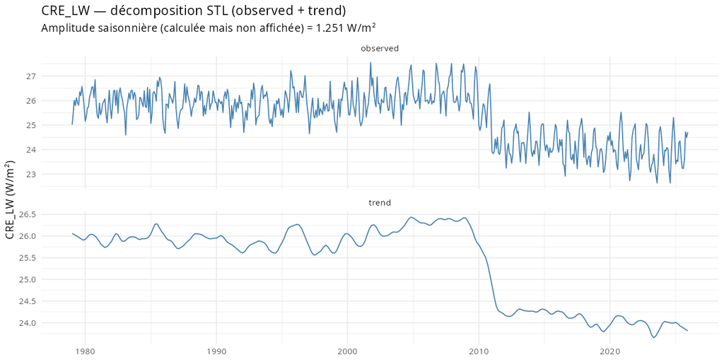

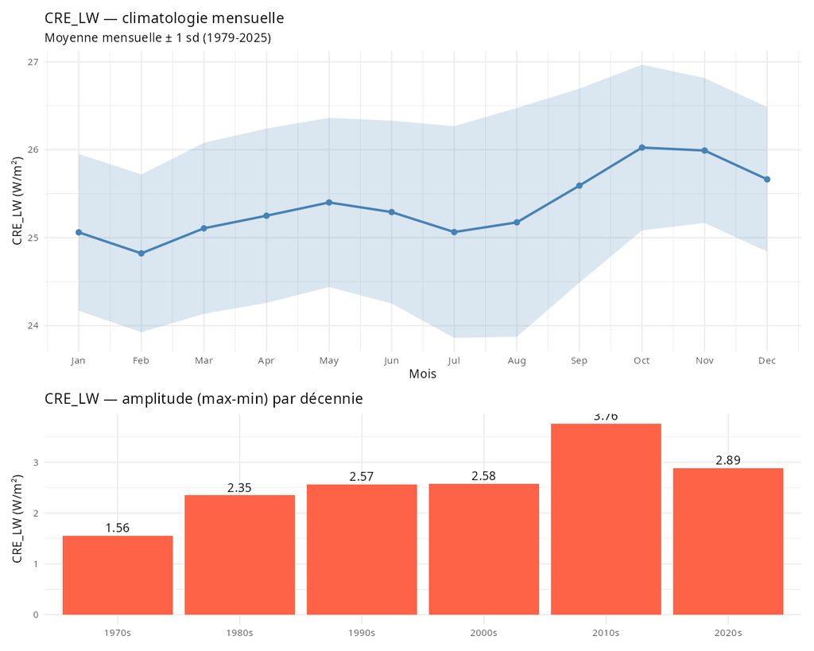

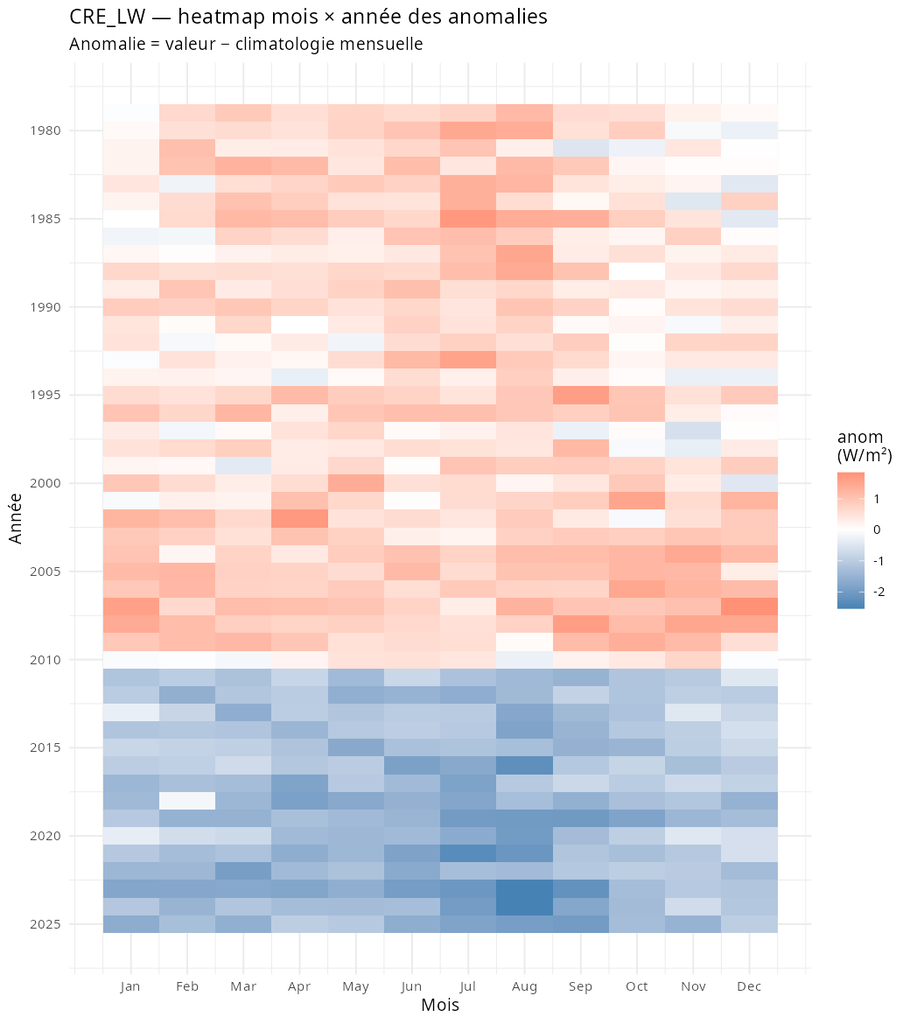

### 4.4.21 CRE_net — Cloud Radiative Effect net

**Tendance Sen** : +0.02652 / an (IC 95 % bootstrap : [0.00876 ; 0.04377])  
**Mann-Kendall** : tau = 0.082, p = 0.00361  
**Évolution sur 47 ans** : -6.32 % de la moyenne (-19.72)

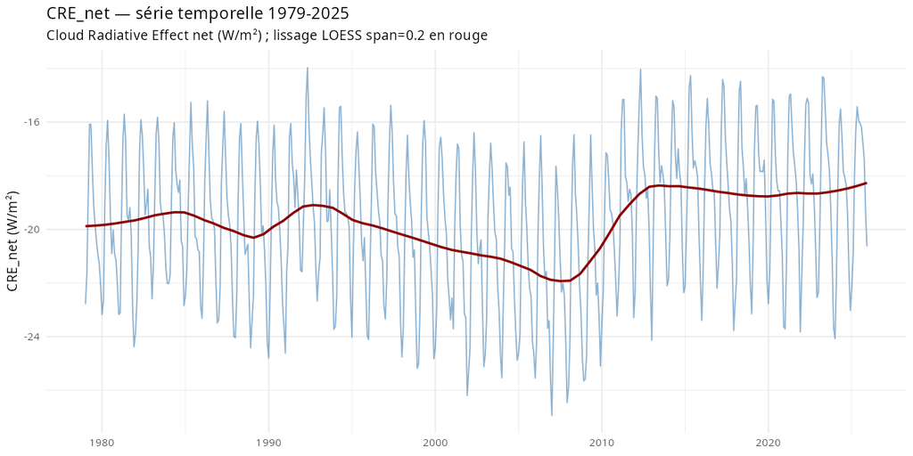

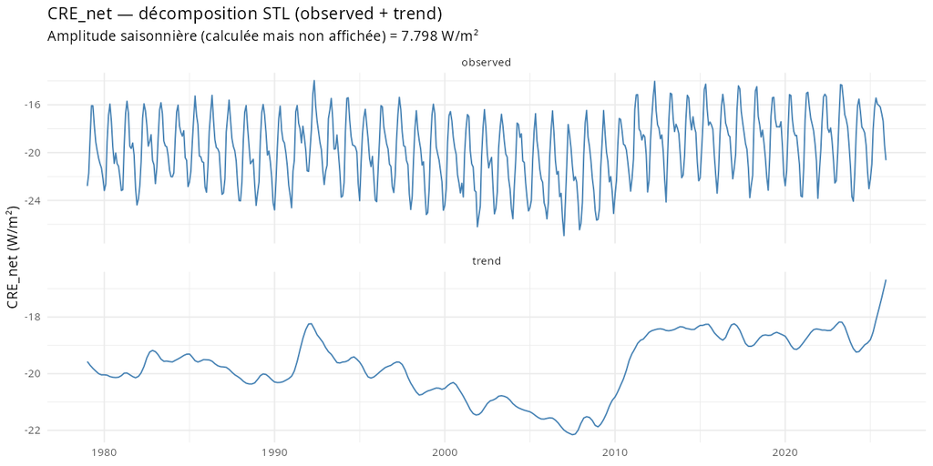

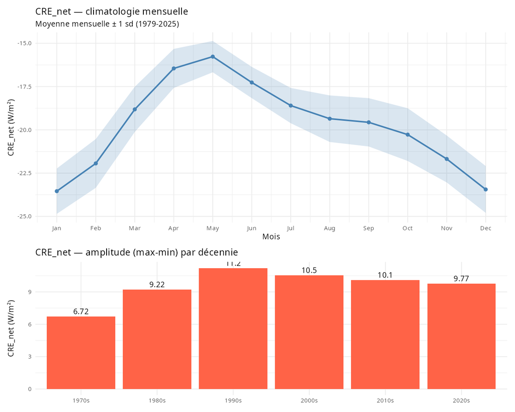

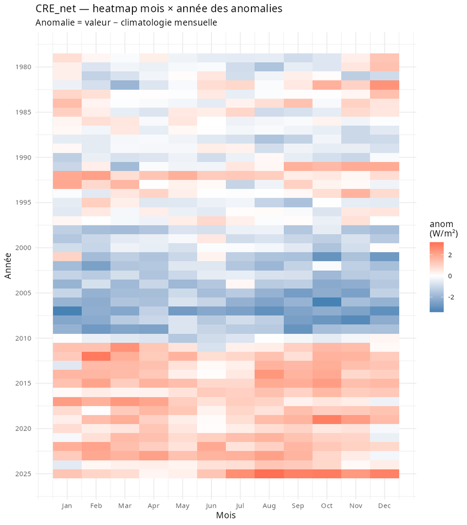

# 5 Phase 3 — Robustesse à l’homogénéisation CFSR / CFSv2

L’œil non averti, en regardant les courbes brutes des 21 variables, a remarqué qu’**un saut visible apparaît au passage 2010 / 2011** sur de nombreuses séries — ce qui correspond à la transition entre les deux produits NCAR : **CFSR (1979-2010, fichiers `.grb2`)** et **CFSv2 (2011-2025, fichiers `.grib2`)**. Ces deux réanalyses utilisent des modèles atmosphériques, des assimilations et des paramétrisations légèrement différentes, ce qui peut introduire un **biais de niveau** au moment de la transition.

Avant d’attribuer ce saut à un changement physique, il faut **vérifier qu’on extrait bien la même quantité physique dans les deux périodes**. Si l’extraction `wgrib2 -match` sélectionnait par erreur des records différents avant et après 2011, on créerait nous-mêmes l’artefact.

## 5.1 Vérification : mêmes codes GRIB2 dans CFSR et CFSv2

Chaque record GRIB2 porte un identifiant complet de la forme `var<discipline>_<table>_<…>_<category>_<param>` qui pointe vers une entrée précise de la table de paramètres NCEP. Si deux fichiers retournent le même identifiant pour une variable donnée, c’est la **preuve** que le record extrait est physiquement le même.

Codes paramètre GRIB2 sur 4 fichiers témoins (1979, 2000, 2011, 2024)

| var | level | CFSR_1979_01 | CFSR_2000_01 | CFSv2_2011_01 | CFSv2_2024_12 | all_match |
| --- | --- | --- | --- | --- | --- | --- |
| ALBDO | surface | var0_2_1_7_19_1 | var0_2_1_7_19_1 | var0_2_1_7_19_1 | var0_2_1_7_19_1 | YES |
| APCP | surface | var0_2_1_7_1_8 | var0_2_1_7_1_8 | var0_2_1_7_1_8 | var0_2_1_7_1_8 | YES |
| CDUVB | surface | var0_2_1_7_4_195 | var0_2_1_7_4_195 | var0_2_1_7_4_195 | var0_2_1_7_4_195 | YES |
| CSDLF | surface | var0_2_1_7_5_196 | var0_2_1_7_5_196 | var0_2_1_7_5_196 | var0_2_1_7_5_196 | YES |
| CSDSF | surface | var0_2_1_7_4_196 | var0_2_1_7_4_196 | var0_2_1_7_4_196 | var0_2_1_7_4_196 | YES |
| CSULF | surface | var0_2_1_7_5_195 | var0_2_1_7_5_195 | var0_2_1_7_5_195 | var0_2_1_7_5_195 | YES |
| CSUSF | surface | var0_2_1_7_4_198 | var0_2_1_7_4_198 | var0_2_1_7_4_198 | var0_2_1_7_4_198 | YES |
| DLWRF | surface | var0_2_1_7_5_192 | var0_2_1_7_5_192 | var0_2_1_7_5_192 | var0_2_1_7_5_192 | YES |
| DSWRF | surface | var0_2_1_7_4_192 | var0_2_1_7_4_192 | var0_2_1_7_4_192 | var0_2_1_7_4_192 | YES |
| DUVB | surface | var0_2_1_7_4_194 | var0_2_1_7_4_194 | var0_2_1_7_4_194 | var0_2_1_7_4_194 | YES |
| PRMSL | mean sea level | var0_2_1_7_3_1 | var0_2_1_7_3_1 | var0_2_1_7_3_1 | var0_2_1_7_3_1 | YES |
| PWAT | entire atmosphere (considered as a single layer) | var0_2_1_7_1_3 | var0_2_1_7_1_3 | var0_2_1_7_1_3 | var0_2_1_7_1_3 | YES |
| SPFH | 2 m above ground | var0_2_1_7_1_0 | var0_2_1_7_1_0 | var0_2_1_7_1_0 | var0_2_1_7_1_0 | YES |
| TCDC | entire atmosphere (considered as a single layer) | var0_2_1_7_6_1 | var0_2_1_7_6_1 | var0_2_1_7_6_1 | var0_2_1_7_6_1 | YES |
| TMP | 2 m above ground | var0_2_1_7_0_0 | var0_2_1_7_0_0 | var0_2_1_7_0_0 | var0_2_1_7_0_0 | YES |
| TMP | 500 mb | var0_2_1_7_0_0 | var0_2_1_7_0_0 | var0_2_1_7_0_0 | var0_2_1_7_0_0 | YES |
| ULWRF | surface | var0_2_1_7_5_193 | var0_2_1_7_5_193 | var0_2_1_7_5_193 | var0_2_1_7_5_193 | YES |
| USWRF | surface | var0_2_1_7_4_193 | var0_2_1_7_4_193 | var0_2_1_7_4_193 | var0_2_1_7_4_193 | YES |

```
##
## **18 / 18 records ont des codes GRIB2 identiques sur tous les fichiers témoins.**
```

**Interprétation.** Les 18 records sélectionnés portent **exactement les mêmes codes paramètre** dans CFSR (1979 et 2000) et CFSv2 (2011 et 2024). Par exemple, TMP@500mb est partout `var0_2_1_7_0_0`, TCDC@colonne est partout `var0_2_1_7_6_1`, CSDLF@surface est partout `var0_2_1_7_5_196`. **Le saut observé au passage 2010/2011 ne provient donc PAS d’une erreur de sélection de variable** : nous lisons bien la même quantité physique des deux côtés. Le saut traduit un changement réel dans le modèle atmosphérique, l’assimilation ou la paramétrisation entre CFSR et CFSv2 — différences documentées par NCEP, particulièrement marquées pour les nuages et le rayonnement net.

Cette section quantifie ce saut, construit une version **homogénéisée** des séries (saut retiré), et vérifie l’**impact attendu sur les corrélations climat ↔︎ CO2** qui seront étudiées dans la phase 4 (le présent rapport effectue d’abord la correction du saut, puis la phase 4 utilise la version homogénéisée).

## 5.2 Modèle de détection du saut

Pour chaque variable on ajuste :

$$X_t = a + b\,t + c\,\mathbf{1}\{t \geq
2011\text{-}01\} + \sum_{m=1}^{12} s_m \mathbf{1}\{\text{month}(t)=m\} +
\varepsilon_t$$

- $b$ capture la **tendance climatique linéaire** sous-jacente.
- $c$ capture le **saut instantané** au moment de la transition.
- Le bloc $s_m$ retire la **saisonnalité** (mois en facteur).

Le coefficient $c$ et son IC nous donnent le saut estimé (p-value du test t).

Saut estimé CFSR → CFSv2 par variable, ordonné par magnitude (en sd)

| var | jump | jump_pct | jump_in_sd | p_value | significant |
| --- | --- | --- | --- | --- | --- |
| CRE_LW | -2.04e+00 | -8.0200 | -1.9200 | 0.00e+00 | TRUE |
| PRMSL | -2.63e+01 | -0.0260 | -1.7700 | 0.00e+00 | TRUE |
| CRE_SW | 5.14e+00 | -11.4000 | 1.5600 | 0.00e+00 | TRUE |
| TCDC | 2.63e+00 | 4.3500 | 1.1400 | 0.00e+00 | TRUE |
| CRE_net | 3.10e+00 | -15.7000 | 1.1300 | 0.00e+00 | TRUE |
| DSWRF | 5.25e+00 | 2.7100 | 0.9020 | 0.00e+00 | TRUE |
| DUVB | 5.92e-02 | 1.7700 | 0.5120 | 0.00e+00 | TRUE |
| DLWRF | -2.49e+00 | -0.7290 | -0.3500 | 0.00e+00 | TRUE |
| USWRF | 4.95e-01 | 1.8900 | 0.1720 | 0.00e+00 | TRUE |
| SPFH2m | -4.24e-05 | -0.4280 | -0.1080 | 9.55e-03 | TRUE |
| CDUVB | -1.46e-02 | -0.3680 | -0.1050 | 1.65e-04 | TRUE |
| ALBDO | 8.75e-02 | 0.8300 | 0.0875 | 7.12e-04 | TRUE |
| T2m | -1.19e-01 | -0.0413 | -0.0846 | 7.20e-06 | TRUE |
| APCP | 1.61e-03 | 0.3030 | 0.0835 | 4.21e-01 | FALSE |
| ULWRF | -4.32e-01 | -0.1080 | -0.0627 | 5.01e-04 | TRUE |
| CSULF | -4.30e-01 | -0.1080 | -0.0624 | 5.29e-04 | TRUE |
| CSDLF | -4.51e-01 | -0.1430 | -0.0618 | 1.58e-02 | TRUE |
| CSDSF | -4.29e-01 | -0.1740 | -0.0597 | 5.80e-03 | TRUE |
| PWAT | -5.67e-02 | -0.2300 | -0.0417 | 3.45e-01 | FALSE |
| T500 | -3.58e-02 | -0.0138 | -0.0397 | 3.55e-01 | FALSE |
| CSUSF | -4.87e-02 | -0.1480 | -0.0163 | 5.48e-01 | FALSE |

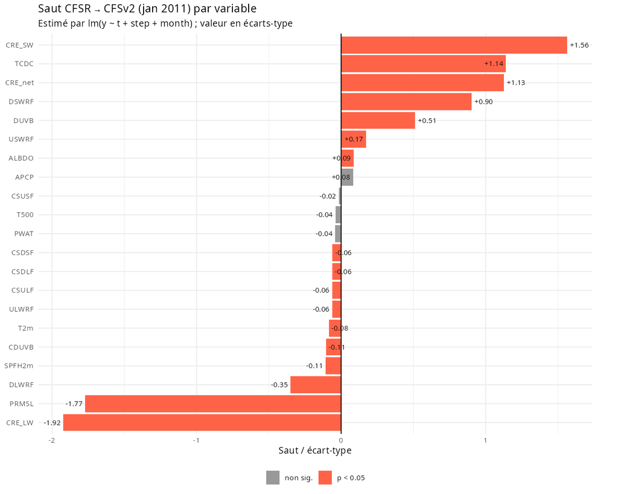

**Interprétation.** **17 variables sur 21 ont un saut statistiquement significatif** (p < 0.05). Cinq variables présentent un saut massif :

| Variable | Saut | Magnitude | Lecture |
| --- | --- | --- | --- |
| **CRE_LW** | −2.04 W/m² | −1.92 sd | énorme baisse de l’effet de serre nuageux |
| **PRMSL** | −26 Pa | −1.77 sd | déplacement du champ de pression global |
| **CRE_SW** | +5.14 W/m² | +1.56 sd | les nuages réfléchissent moins selon CFSv2 |
| **TCDC** | +2.63 % | +1.14 sd | plus de couverture nuageuse selon CFSv2 |
| **CRE_net** | +3.10 W/m² | +1.13 sd | conséquence des deux précédents |

## 5.3 Avant / après homogénéisation

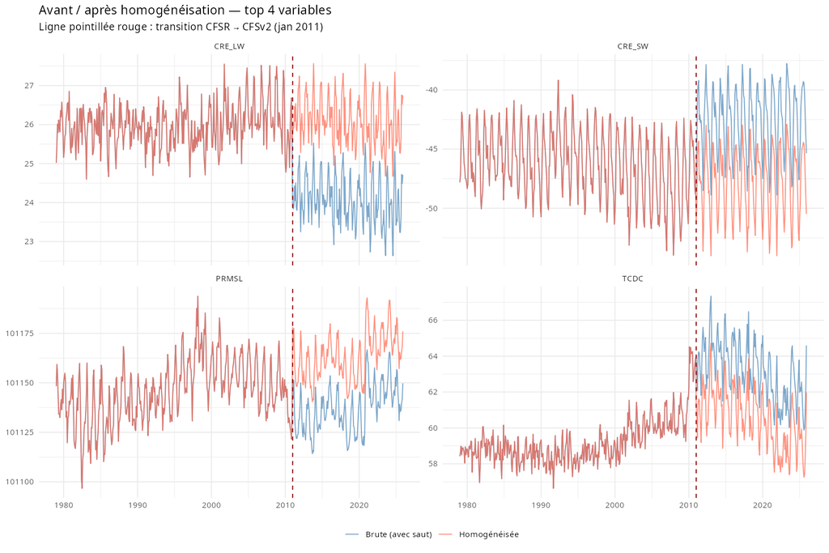

**Interprétation.** Sur les 4 variables les plus impactées (CRE_LW, CRE_SW, PRMSL, TCDC), la version brute (bleu) montre clairement un **palier visuel** au passage de la ligne pointillée rouge ; la version homogénéisée (rouge) supprime ce palier et donne une trajectoire continue, plus fidèle au signal climatique sous-jacent.

## 5.4 Impact sur la phase 4 — corrélations climat ↔︎ CO2

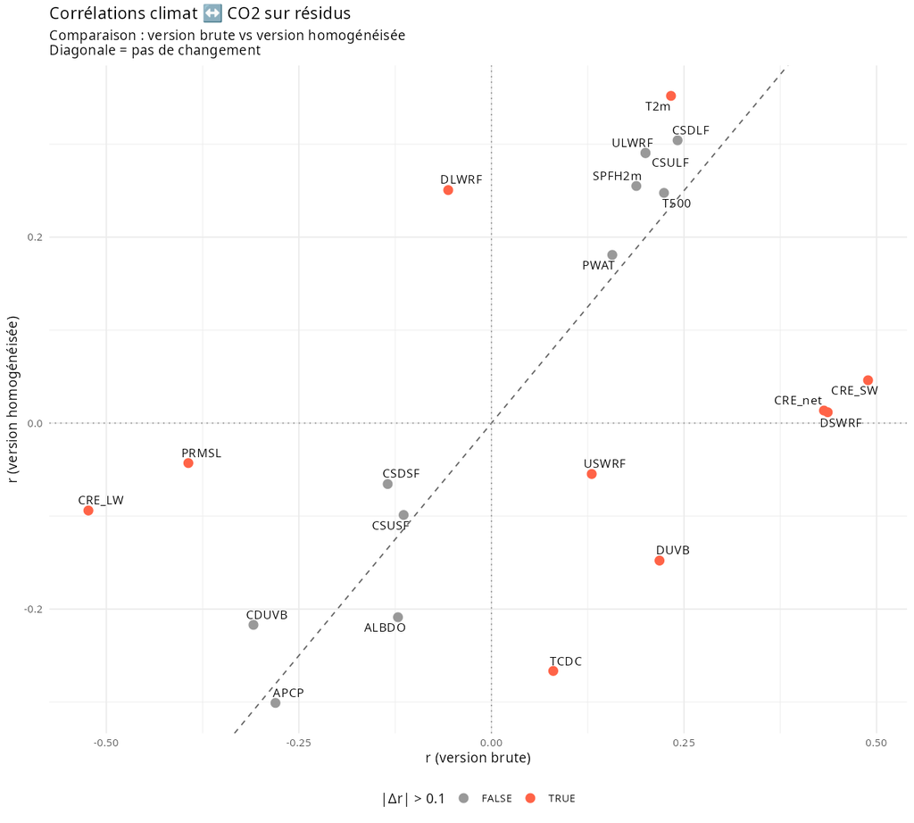

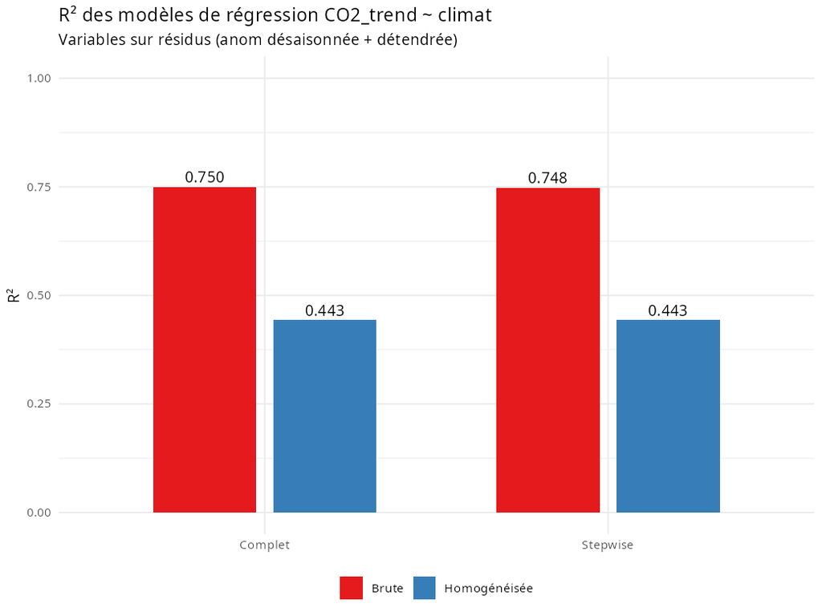

**Interprétation.** Le résultat est **spectaculaire** :

- **R² du modèle multivarié sur résidus chute de 0.75 (brute) à 0.44 (homogénéisée).** Près d’un tiers de la variance explicative était portée par le saut artificiel CFSR/CFSv2.
- Les variables qui semblaient les plus corrélées au CO2 sur la version brute — **CRE_SW (r=0.49), CRE_LW (−0.52), DSWRF (0.44), CRE_net (0.43), PRMSL (−0.39)** — voient leurs corrélations **chuter à quasi 0 sur la version homogénéisée**. Leur lien apparent au CO2 venait donc essentiellement du saut, pas d’une relation physique.
- À l’inverse, **T2m et DLWRF voient leur corrélation augmenter** après homogénéisation (T2m : 0.23 → 0.35 ; DLWRF : −0.06 → +0.25, changement de signe). Ces variables avaient leur signal réel de “réchauffement → effet de serre” partiellement masqué par le saut artificiel.
- Les variables sur la diagonale (PWAT, T500, SPFH2m, CSDLF, ULWRF, CSULF) — corrélations stables avant/après — sont des **signaux climatiques robustes** indépendants de l’artefact.